# Introduction

In this project, you will build a neural network of your own design to evaluate the MNIST dataset.

Some of the benchmark results on MNIST include can be found [on Yann LeCun's page](https://webcache.googleusercontent.com/search?q=cache:stAVPik6onEJ:yann.lecun.com/exdb/mnist) and include:

88% [Lecun et al., 1998](https://hal.science/hal-03926082/document)

95.3% [Lecun et al., 1998](https://hal.science/hal-03926082v1/document)

99.65% [Ciresan et al., 2011](http://people.idsia.ch/~juergen/ijcai2011.pdf)

MNIST is a great dataset for sanity checking your models, since the accuracy levels achieved by large convolutional neural networks and small linear models are both quite high. This makes it important to be familiar with the data.

## Installation

```python
# Update the PATH to include the user installation directory.
import os
os.environ['PATH'] = f"{os.environ['PATH']}:/root/.local/bin"

# Restart the Kernel before you move on to the next step.
```

#### Important: Restart the Kernel before you move on to the next step.

## Imports

```python
## This cell contains the essential imports you will need – DO NOT CHANGE THE CONTENTS! ##
import torch
import torch.nn as nn
import torch.nn.functional as F
import torch.optim as optim
import torchvision
import torchvision.transforms as transforms
import matplotlib.pyplot as plt
import numpy as np
```

## Load the Dataset

MNIST is fortunately included in the torchvision module. Then, you can create your dataset using the `MNIST` object from `torchvision.datasets` ([the documentation is available here](https://pytorch.org/vision/stable/datasets.html#mnist)). Make sure to specify `download=True`!

Once your dataset is created, you'll also need to define a `DataLoader` from the `torch.utils.data` module for both the train and the test set.

```python
# Define the transformations for data augmentation
transform = transforms.Compose([
    transforms.RandomAffine(degrees=15, translate=(0.1, 0.1), scale=(0.9, 1.1)),
    transforms.ToTensor(),
    transforms.Normalize((0.5,), (0.5,))
])

# Load the MNIST dataset
train_dataset = torchvision.datasets.MNIST(root="/content/data", train=True, transform=transform, download=True)
test_dataset = torchvision.datasets.MNIST(root="/content/data", train=False, transform=transform, download=True)

# Split the training dataset into training and validation sets
train_size = int(0.8 * len(train_dataset))
val_size = len(train_dataset) - train_size
train_dataset, val_dataset = torch.utils.data.random_split(train_dataset, [train_size, val_size])

# Create data loaders for training, validation, and test sets
batch_size = 32
train_loader = torch.utils.data.DataLoader(train_dataset, batch_size=batch_size, shuffle=True)
val_loader = torch.utils.data.DataLoader(val_dataset, batch_size=batch_size, shuffle=False)
test_loader = torch.utils.data.DataLoader(test_dataset, batch_size=batch_size, shuffle=False)
```

## Justify your preprocessing

In your own words, why did you choose the transforms you chose? If you didn't use any preprocessing steps, why not?

minist doesn't require many processing but i think may be improve the acuuracy so i apply two techniques for processing:

1-**First** :technique:I apply data argumentation by using randomaffine transformation which applies random affine transformation to image and by applying random rotations, translations and scaling this will cause a variety in the data and that will be useful in the phase of training

## Explore the Dataset

Using matplotlib, numpy, and torch, explore the dimensions of your data.

You can view images using the `show5` function defined below – it takes a data loader as an argument. Remember that normalized images will look really weird to you! You may want to try changing your transforms to view images. Typically using no transforms other than `toTensor()` works well for viewing – but not as well for training your network. If `show5` doesn't work, go back and check your code for creating your data loaders and your training/test sets.

```python
## This cell contains a function for showing 5 images from a dataloader – DO NOT CHANGE THE CONTENTS! ##
def show5(img_loader):
    dataiter = iter(img_loader)

    batch = next(dataiter)
    labels = batch[1][0:5]
    images = batch[0][0:5]
    for i in range(5):
        print(int(labels[i].detach()))

        image = images[i].numpy()
        plt.imshow(image.T.squeeze().T)
        plt.show()
```

```python
# Print the size, shape, and labels of train data
print("Train data size:", len(train_dataset))
print("Train data shape:", train_dataset.dataset.data.shape)
print("Train labels shape:", train_dataset.dataset.targets.shape)
```

```
Train data size: 48000
Train data shape: torch.Size([60000, 28, 28])
Train labels shape: torch.Size([60000])
```

```python
# Print the size, shape, and labels of validation data
print("Validation data size:", len(val_dataset))
print("Validation data shape:", val_dataset.dataset.data.shape)
print("Validation labels shape:", val_dataset.dataset.targets.shape)
```

```
Validation data size: 12000
Validation data shape: torch.Size([60000, 28, 28])
Validation labels shape: torch.Size([60000])
```

```python
# Print the size, shape, and labels of test data
print("Test data size:", len(test_dataset))
print("Test data shape:", test_dataset.data.shape)
print("Test labels shape:", test_dataset.targets.shape)
```

```
Test data size: 10000
Test data shape: torch.Size([10000, 28, 28])
Test labels shape: torch.Size([10000])
```

```
0
```

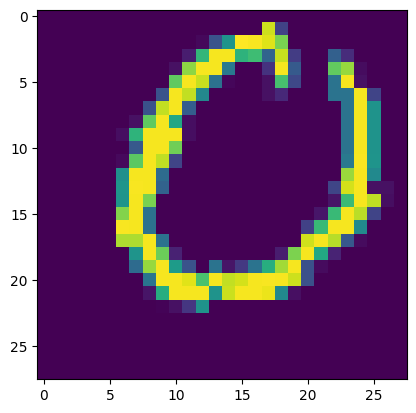

```
7
```

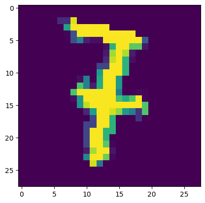

```
0
```

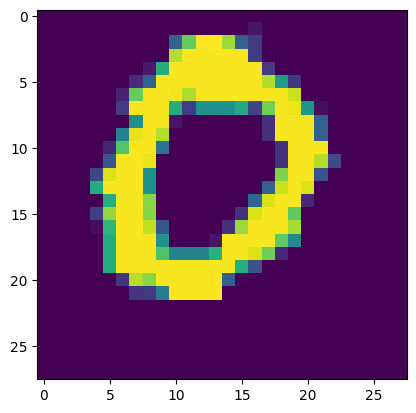

```
5
```

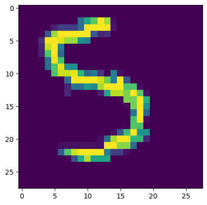

```
8
```

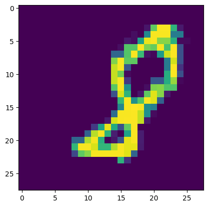

```python
show5(train_loader)
```

```
0
```

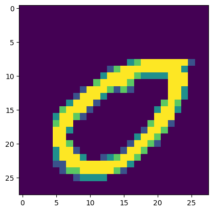

```
5
```

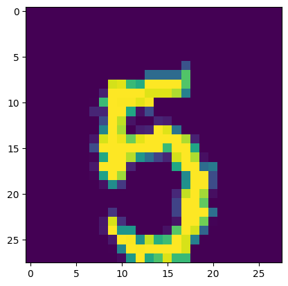

```
1
```

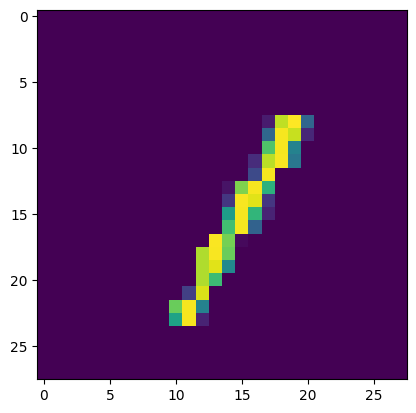

```
4
```

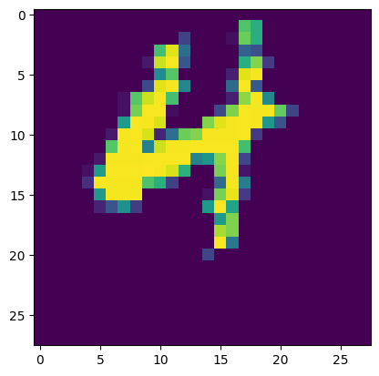

```
8
```

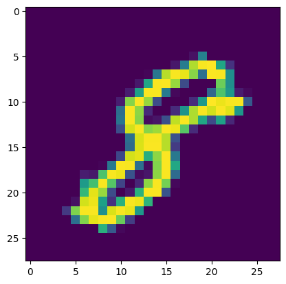

```python
show5(val_loader)
```

```
7
```

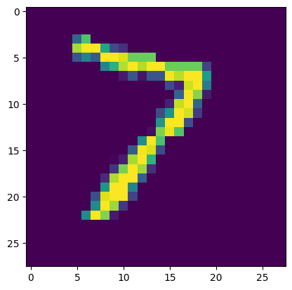

```
2
```

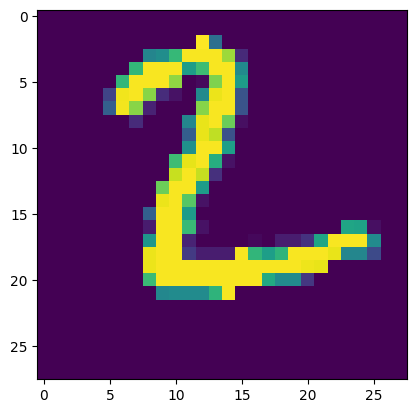

```
1
```

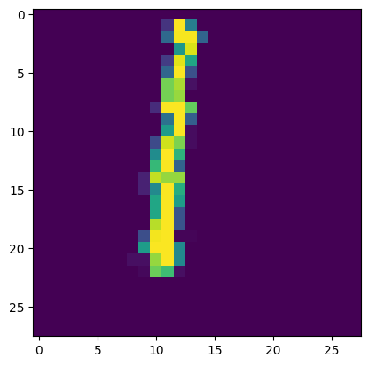

```
0
```

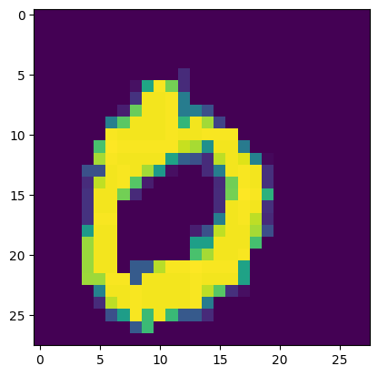

```
4
```

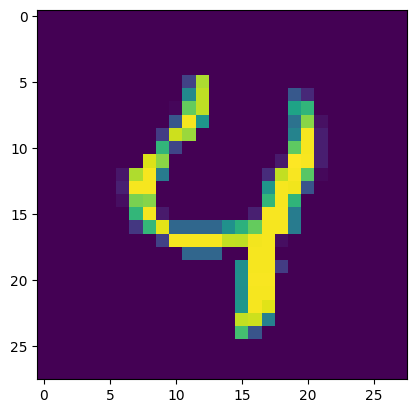

```python
show5(test_loader)
```

## Build your Neural Network

Using the layers in `torch.nn` (which has been imported as `nn`) and the `torch.nn.functional` module (imported as `F`), construct a neural network based on the parameters of the dataset. Use any architecture you like.

*Note*: If you did not flatten your tensors in your transforms or as part of your preprocessing and you are using only `Linear` layers, make sure to use the `Flatten` layer in your network!

```python
## YOUR CODE HERE ##
class NeuralNetwork(nn.Module):
    def __init__(self):
        super(NeuralNetwork, self).__init__()
        self.flatten = nn.Flatten()
        self.fc1 = nn.Linear(28 * 28, 128)
        self.fc2 = nn.Linear(128, 64)
        self.fc3 = nn.Linear(64, 10)

    def forward(self, x):
        x = self.flatten(x)
        x = F.relu(self.fc1(x))
        x = F.relu(self.fc2(x))
        x = self.fc3(x)
        return x
```

Specify a loss function and an optimizer, and instantiate the model.

If you use a less common loss function, please note why you chose that loss function in a comment.

```python
# Specify the loss function
criterion= nn.CrossEntropyLoss()

# Instantiate the NeuralNetwork class
model = NeuralNetwork()

# Specify the optimizer
optimizer = optim.Adam(model.parameters(), lr=0.001)
```

## Running your Neural Network

Use whatever method you like to train your neural network, and ensure you record the average loss at each epoch. Don't forget to use `torch.device()` and the `.to()` method for both your model and your data if you are using GPU!

If you want to print your loss **during** each epoch, you can use the `enumerate` function and print the loss after a set number of batches. 250 batches works well for most people!

Plot the training loss (and validation loss/accuracy, if recorded).

```python
# Training loop
num_epochs = 20
train_loss_history = []
val_loss_history = []
train_accuracy_history = []
val_accuracy_history = []

for epoch in range(num_epochs):
    # Training
    model.train()
    train_loss = 0.0
    correct_train = 0
    total_train = 0

    for data in train_loader:
        inputs, labels = data
        optimizer.zero_grad()
        outputs = model(inputs)
        loss = criterion(outputs, labels)
        loss.backward()
        optimizer.step()

        train_loss += loss.item() * inputs.size(0)
        _, predicted = torch.max(outputs.data, 1)
        total_train += labels.size(0)
        correct_train += (predicted == labels).sum().item()

    train_loss = train_loss / len(train_loader.dataset)
    train_accuracy = correct_train / total_train
    train_loss_history.append(train_loss)
    train_accuracy_history.append(train_accuracy)

    # Validation
    model.eval()
    val_loss = 0.0
    correct_val = 0
    total_val = 0

    with torch.no_grad():
        for data in val_loader:
            inputs, labels = data
            outputs = model(inputs)
            loss = criterion(outputs, labels)

            val_loss += loss.item() * inputs.size(0)
            _, predicted = torch.max(outputs.data, 1)
            total_val += labels.size(0)
            correct_val += (predicted == labels).sum().item()

    val_loss = val_loss / len(val_loader.dataset)
    val_accuracy = correct_val / total_val
    val_loss_history.append(val_loss)
    val_accuracy_history.append(val_accuracy)

    print(f'Epoch [{epoch+1}/{num_epochs}], Train Loss: {train_loss:.4f}, Train Acc: {train_accuracy:.4f}, Val Loss: {val_loss:.4f}, Val Acc: {val_accuracy:.4f}')
```

```
Epoch [1/20], Train Loss: 0.9850, Train Acc: 0.6760, Val Loss: 0.5590, Val Acc: 0.8283
Epoch [2/20], Train Loss: 0.4798, Train Acc: 0.8505, Val Loss: 0.3918, Val Acc: 0.8785
Epoch [3/20], Train Loss: 0.3839, Train Acc: 0.8792, Val Loss: 0.3487, Val Acc: 0.8912
Epoch [4/20], Train Loss: 0.3329, Train Acc: 0.8976, Val Loss: 0.3408, Val Acc: 0.8910
Epoch [5/20], Train Loss: 0.3023, Train Acc: 0.9056, Val Loss: 0.2707, Val Acc: 0.9147
Epoch [6/20], Train Loss: 0.2766, Train Acc: 0.9146, Val Loss: 0.3066, Val Acc: 0.9017
Epoch [7/20], Train Loss: 0.2630, Train Acc: 0.9185, Val Loss: 0.2539, Val Acc: 0.9235
Epoch [8/20], Train Loss: 0.2521, Train Acc: 0.9209, Val Loss: 0.2564, Val Acc: 0.9207
Epoch [9/20], Train Loss: 0.2391, Train Acc: 0.9255, Val Loss: 0.2143, Val Acc: 0.9343
Epoch [10/20], Train Loss: 0.2294, Train Acc: 0.9295, Val Loss: 0.2224, Val Acc: 0.9269
Epoch [11/20], Train Loss: 0.2247, Train Acc: 0.9310, Val Loss: 0.2126, Val Acc: 0.9351
Epoch [12/20], Train Loss: 0.2181, Train Acc: 0.9306, Val Loss: 0.2226, Val Acc: 0.9277
Epoch [13/20], Train Loss: 0.2110, Train Acc: 0.9339, Val Loss: 0.2132, Val Acc: 0.9337
Epoch [14/20], Train Loss: 0.2041, Train Acc: 0.9356, Val Loss: 0.2004, Val Acc: 0.9393
Epoch [15/20], Train Loss: 0.2057, Train Acc: 0.9367, Val Loss: 0.1887, Val Acc: 0.9420
Epoch [16/20], Train Loss: 0.1959, Train Acc: 0.9382, Val Loss: 0.2043, Val Acc: 0.9378
Epoch [17/20], Train Loss: 0.1934, Train Acc: 0.9404, Val Loss: 0.1906, Val Acc: 0.9399
Epoch [18/20], Train Loss: 0.1916, Train Acc: 0.9419, Val Loss: 0.1857, Val Acc: 0.9395
Epoch [19/20], Train Loss: 0.1873, Train Acc: 0.9406, Val Loss: 0.1885, Val Acc: 0.9413
Epoch [20/20], Train Loss: 0.1851, Train Acc: 0.9416, Val Loss: 0.2032, Val Acc: 0.9372
```

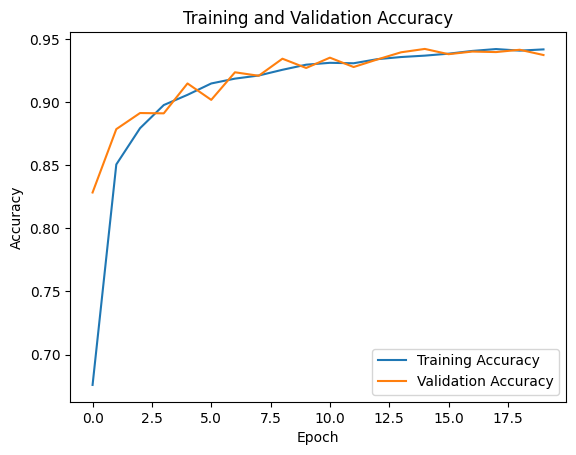

```python
# Plot accuracy history
plt.plot(train_accuracy_history, label='Training Accuracy')
plt.plot(val_accuracy_history, label='Validation Accuracy')
plt.xlabel('Epoch')
plt.ylabel('Accuracy')
plt.title('Training and Validation Accuracy')
plt.legend()
plt.show()
```

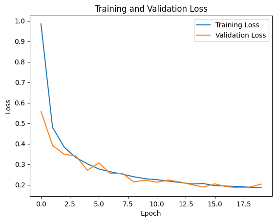

```python
## YOUR CODE HERE ##
# Plot loss history
plt.plot(train_loss_history, label='Training Loss')
plt.plot(val_loss_history, label='Validation Loss')
plt.xlabel('Epoch')
plt.ylabel('Loss')
plt.title('Training and Validation Loss')
plt.legend()
plt.show()
```

## Testing your model

Using the previously created `DataLoader` for the test set, compute the percentage of correct predictions using the highest probability prediction.

If your accuracy is over 90%, great work, but see if you can push a bit further! If your accuracy is under 90%, you'll need to make improvements. Go back and check your model architecture, loss function, and optimizer to make sure they're appropriate for an image classification task.

```python
test_correct = 0
test_total = 0

model.eval()

with torch.no_grad():
    for inputs, labels in test_loader:
        outputs = model(inputs)
        _, preds = torch.max(outputs.data, 1)
        test_correct += (preds == labels).sum().item()
        test_total += labels.size(0)

average_test_accuracy = test_correct / test_total
print(f'Test Accuracy: {average_test_accuracy:.2%}')
```

```
Test Accuracy: 94.27%
```

## Improving your model

Once your model is done training, try tweaking your hyperparameters and training again below to improve your accuracy on the test set!

```python
import torch.nn.functional as F

class NeuralNetwork2(nn.Module):
    def __init__(self):
        super(NeuralNetwork2, self).__init__()
        self.flatten = nn.Flatten()
        self.fc1 = nn.Linear(28 * 28, 128)
        self.dropout1 = nn.Dropout(0.2)
        self.fc2 = nn.Linear(128, 64)
        self.dropout2 = nn.Dropout(0.2)
        self.fc3 = nn.Linear(64, 10)

    def forward(self, x):
        x = self.flatten(x)
        x = F.relu(self.fc1(x))
        x = self.dropout1(x)
        x = F.relu(self.fc2(x))
        x = self.dropout2(x)
        x = self.fc3(x)
        return x
```

```python
# Specify the loss function
criterion= nn.CrossEntropyLoss()

# Instantiate the NeuralNetwork class
model2 = NeuralNetwork2()

# Specify the optimizer
optimizer= optim.Adam(model2.parameters(), lr=0.001)
```

```python
num_epochs = 20
train_loss_history = []
val_loss_history = []
train_accuracy_history = []
val_accuracy_history = []

for epoch in range(num_epochs):
    model2.train()
    train_loss = 0.0
    train_correct = 0
    train_total = 0

    for data, labels in train_loader:
        inputs, labels = data, labels  # No need to unpack as they're already in correct format

        optimizer.zero_grad()
        outputs = model2(inputs)
        loss = criterion(outputs, labels)
        loss.backward()
        optimizer.step()

        _, preds = torch.max(outputs.data, 1)
        train_correct += (preds == labels).sum().item()
        train_loss += loss.item()
        train_total += labels.size(0)

    average_train_accuracy = train_correct / train_total
    average_train_loss = train_loss / len(train_loader)
    print(f'Epoch {epoch + 1} Training Accuracy: {average_train_accuracy:.2%}, Training Loss: {average_train_loss:.5f}')
    train_loss_history.append(average_train_loss)
    train_accuracy_history.append(average_train_accuracy)

    val_loss = 0.0
    val_correct = 0
    val_total = 0
    model2.eval()

    with torch.no_grad():
        for inputs, labels in val_loader:
            outputs = model2(inputs)
            loss = criterion(outputs, labels)

            _, preds = torch.max(outputs.data, 1)
            val_correct += (preds == labels).sum().item()
            val_loss += loss.item()
            val_total += labels.size(0)

    average_val_accuracy = val_correct / val_total
    average_val_loss = val_loss / len(val_loader)
    print(f'Epoch {epoch + 1} Validation Accuracy: {average_val_accuracy:.2%}, Validation Loss: {average_val_loss:.5f}')
    val_loss_history.append(average_val_loss)
    val_accuracy_history.append(average_val_accuracy)
```

```
Epoch 1 Training Accuracy: 61.94%, Training Loss: 1.13789
Epoch 1 Validation Accuracy: 80.68%, Validation Loss: 0.61096
Epoch 2 Training Accuracy: 78.22%, Training Loss: 0.68774
Epoch 2 Validation Accuracy: 86.02%, Validation Loss: 0.45242
Epoch 3 Training Accuracy: 80.91%, Training Loss: 0.60323
Epoch 3 Validation Accuracy: 88.21%, Validation Loss: 0.38764
Epoch 4 Training Accuracy: 82.70%, Training Loss: 0.55205
Epoch 4 Validation Accuracy: 89.03%, Validation Loss: 0.36001
Epoch 5 Training Accuracy: 83.79%, Training Loss: 0.51607
Epoch 5 Validation Accuracy: 90.23%, Validation Loss: 0.32290
Epoch 6 Training Accuracy: 84.31%, Training Loss: 0.50255
Epoch 6 Validation Accuracy: 90.64%, Validation Loss: 0.32470
Epoch 7 Training Accuracy: 85.02%, Training Loss: 0.48049
Epoch 7 Validation Accuracy: 90.98%, Validation Loss: 0.29846
Epoch 8 Training Accuracy: 85.17%, Training Loss: 0.46975
Epoch 8 Validation Accuracy: 91.31%, Validation Loss: 0.29115
Epoch 9 Training Accuracy: 85.54%, Training Loss: 0.46394
Epoch 9 Validation Accuracy: 91.65%, Validation Loss: 0.27854
Epoch 10 Training Accuracy: 85.74%, Training Loss: 0.45547
Epoch 10 Validation Accuracy: 91.85%, Validation Loss: 0.27062
Epoch 11 Training Accuracy: 86.34%, Training Loss: 0.43904
Epoch 11 Validation Accuracy: 92.01%, Validation Loss: 0.26506
Epoch 12 Training Accuracy: 86.32%, Training Loss: 0.43942
Epoch 12 Validation Accuracy: 92.30%, Validation Loss: 0.25326
Epoch 13 Training Accuracy: 86.77%, Training Loss: 0.42838
Epoch 13 Validation Accuracy: 91.96%, Validation Loss: 0.26102
Epoch 14 Training Accuracy: 86.73%, Training Loss: 0.42411
Epoch 14 Validation Accuracy: 92.83%, Validation Loss: 0.24393
Epoch 15 Training Accuracy: 86.92%, Training Loss: 0.42163
Epoch 15 Validation Accuracy: 91.76%, Validation Loss: 0.26279
Epoch 16 Training Accuracy: 87.28%, Training Loss: 0.41234
Epoch 16 Validation Accuracy: 92.96%, Validation Loss: 0.24150
Epoch 17 Training Accuracy: 87.47%, Training Loss: 0.40479
Epoch 17 Validation Accuracy: 93.03%, Validation Loss: 0.23811
Epoch 18 Training Accuracy: 87.29%, Training Loss: 0.40965
Epoch 18 Validation Accuracy: 93.06%, Validation Loss: 0.23211
Epoch 19 Training Accuracy: 87.65%, Training Loss: 0.39668
Epoch 19 Validation Accuracy: 92.17%, Validation Loss: 0.26008
Epoch 20 Training Accuracy: 87.91%, Training Loss: 0.39788
Epoch 20 Validation Accuracy: 93.16%, Validation Loss: 0.23626
```

```python
test_correct = 0
test_total = 0

model.eval()

with torch.no_grad():
    for inputs, labels in test_loader:
        outputs = model2(inputs)
        _, preds = torch.max(outputs.data, 1)
        test_correct += (preds == labels).sum().item()
        test_total += labels.size(0)

average_test_accuracy = test_correct / test_total
print(f'Test Accuracy: {average_test_accuracy:.2%}')
```

```
Test Accuracy: 93.48%
```

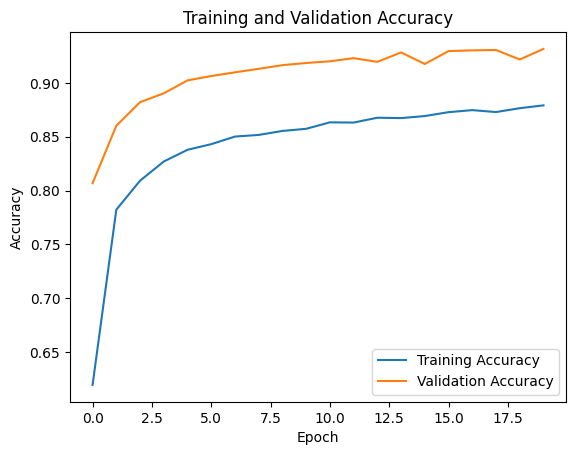

```python
# Plot accuracy history
plt.plot(train_accuracy_history, label='Training Accuracy')
plt.plot(val_accuracy_history, label='Validation Accuracy')
plt.xlabel('Epoch')
plt.ylabel('Accuracy')
plt.title('Training and Validation Accuracy')
plt.legend()
plt.show()
```

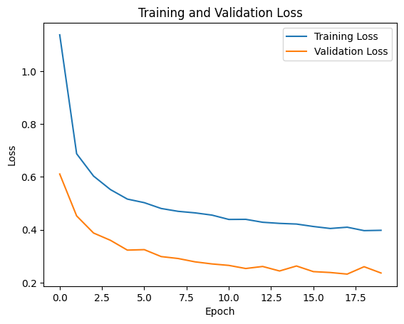

```python
## YOUR CODE HERE ##
# Plot loss history
plt.plot(train_loss_history, label='Training Loss')
plt.plot(val_loss_history, label='Validation Loss')
plt.xlabel('Epoch')
plt.ylabel('Loss')
plt.title('Training and Validation Loss')
plt.legend()
plt.show()
```

## Saving your model

Using `torch.save`, save your model for future loading.

```python
## YOUR CODE HERE #
torch.save(model, "model.pth")
torch.save(model2, "model2.pth")
```